# Simulation Analysis Report

Comparing Conservative, Realistic, and Optimistic Effect Scenarios

Author

Simulation Study

Published

February 10, 2026

## Introduction

This report presents a comprehensive analysis of simulation results across three effect scenarios:

- **Conservative**: Smaller effect sizes with stricter criteria
- **Realistic**: Moderate effect sizes with balanced criteria
- **Optimistic**: Larger effect sizes with more lenient criteria

The analysis examines effect sizes across three time windows (0-10s, 10-20s, 20-60s) and hypothesis support rates.

## Data Loading and Preparation

```r
library(tidyverse)
library(knitr)

# Ensure proper relative path if rendering from reports/qmd/
# If rendering from project root, adjusted path logic is needed.
# Here we assume the knitting root is set to the project directory (common stricture)
# or we dynamically find the scripts folder.

# Source the centralized data loader
# Note: Adjust path depending on where you render from.
# Assuming project root context for now.
source("../../scripts/load_results.R")

# Load simulation results
all_data <- load_simulation_results(data_dir = "../../data/csv")
```

```
Loading simulation_results_optimistic.csv...
Loading simulation_results_realistic.csv...
Loading simulation_results_conservative.csv...
```

```r
cat("Data loaded successfully!\n")
```

```
Data loaded successfully!
```

```r
cat("Total simulations:", nrow(all_data), "\n")
```

```
Total simulations: 162
```

```r
cat("Time windows analyzed: 0-10s, 10-20s, 20-60s\n")
```

```
Time windows analyzed: 0-10s, 10-20s, 20-60s
```

## Summary Statistics

### Overall Sample Sizes

```r
sample_summary <- all_data %>%
  group_by(scenario) %>%
  summarise(
    N_Simulations = n(),
    Mean_Participants = mean(n_participants),
    Range_Participants = paste(min(n_participants), "-", max(n_participants))
  )

kable(sample_summary, digits = 1, caption = "Sample Characteristics by Scenario")
```

Sample Characteristics by Scenario

| scenario | N_Simulations | Mean_Participants | Range_Participants |
| --- | --- | --- | --- |
| Conservative | 51 | 60.6 | 60 - 90 |
| Realistic | 54 | 62.2 | 60 - 90 |
| Optimistic | 57 | 64.7 | 60 - 120 |

### Effect Sizes by Time Window

```r
effect_summary <- all_data %>%
  group_by(scenario) %>%
  summarise(
    Effect_0_10s_Mean = mean(mean_0_10s, na.rm = TRUE),
    Effect_0_10s_SD = sd(mean_0_10s, na.rm = TRUE),
    Effect_10_20s_Mean = mean(mean_10_20s, na.rm = TRUE),
    Effect_10_20s_SD = sd(mean_10_20s, na.rm = TRUE),
    Effect_20_60s_Mean = mean(mean_20_60s, na.rm = TRUE),
    Effect_20_60s_SD = sd(mean_20_60s, na.rm = TRUE)
  )

kable(effect_summary, digits = 4,
      caption = "Mean Effect Sizes ± SD by Time Window")
```

Mean Effect Sizes ± SD by Time Window

| scenario | Effect_0_10s_Mean | Effect_0_10s_SD | Effect_10_20s_Mean | Effect_10_20s_SD | Effect_20_60s_Mean | Effect_20_60s_SD |
| --- | --- | --- | --- | --- | --- | --- |
| Conservative | 0.2398 | 0.0285 | 0.1194 | 0.0278 | 0.0017 | 0.0227 |
| Realistic | 0.3479 | 0.0269 | 0.1537 | 0.0224 | -0.0034 | 0.0286 |
| Optimistic | 0.4928 | 0.0186 | 0.2478 | 0.0225 | 0.0131 | 0.0296 |

### Hypothesis Support Rates

```r
h2_summary <- all_data %>%
  group_by(scenario) %>%
  summarise(
    H2_Support_Rate_Pct = mean(h2_supported, na.rm = TRUE) * 100,
    N_Supported = sum(h2_supported, na.rm = TRUE)
  )

kable(h2_summary, digits = 2,
      caption = "H2 Hypothesis Support Rates")
```

H2 Hypothesis Support Rates

| scenario | H2_Support_Rate_Pct | N_Supported |
| --- | --- | --- |
| Conservative | 98.04 | 50 |
| Realistic | 92.59 | 50 |
| Optimistic | 87.72 | 50 |

## Visualizations

### Distribution Comparison: 0-10s Time Window

The 0-10s window shows the most pronounced differences across scenarios.

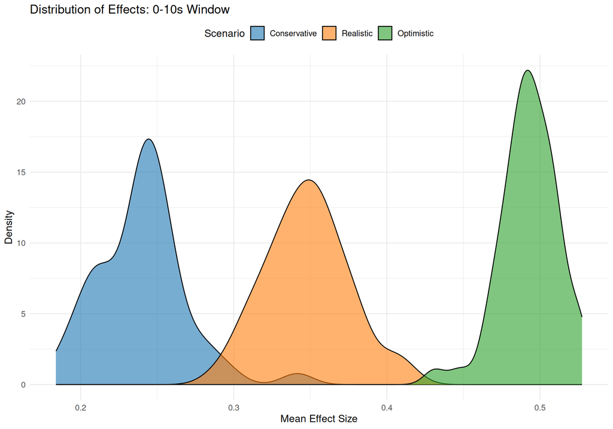

```r
ggplot(all_data, aes(x = mean_0_10s, fill = scenario)) +
  geom_density(alpha = 0.6) +
  scale_fill_manual(values = c("Conservative" = "#1f77b4",
                               "Realistic" = "#ff7f0e",
                               "Optimistic" = "#2ca02c")) +
  labs(title = "Distribution of Effects: 0-10s Window",
       x = "Mean Effect Size",
       y = "Density",
       fill = "Scenario") +
  theme_minimal() +
  theme(legend.position = "top", text = element_text(size = 12))
```

### Distribution Comparison: 10-20s Time Window

The 10-20s window shows moderate effects, declining with time.

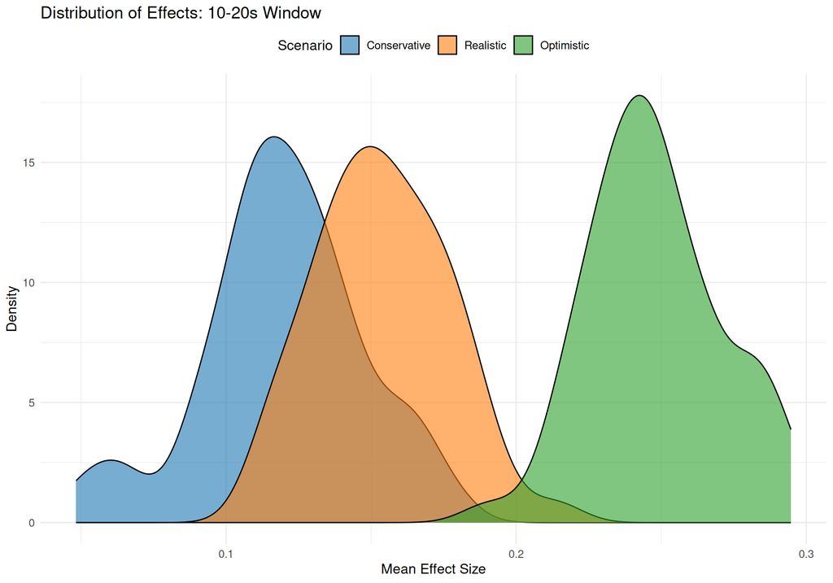

```r
ggplot(all_data, aes(x = mean_10_20s, fill = scenario)) +
  geom_density(alpha = 0.6) +
  scale_fill_manual(values = c("Conservative" = "#1f77b4",
                               "Realistic" = "#ff7f0e",
                               "Optimistic" = "#2ca02c")) +
  labs(title = "Distribution of Effects: 10-20s Window",
       x = "Mean Effect Size",
       y = "Density",
       fill = "Scenario") +
  theme_minimal() +
  theme(legend.position = "top", text = element_text(size = 12))
```

### Distribution Comparison: 20-60s Time Window

The 20-60s window shows minimal and unstable effects near zero.

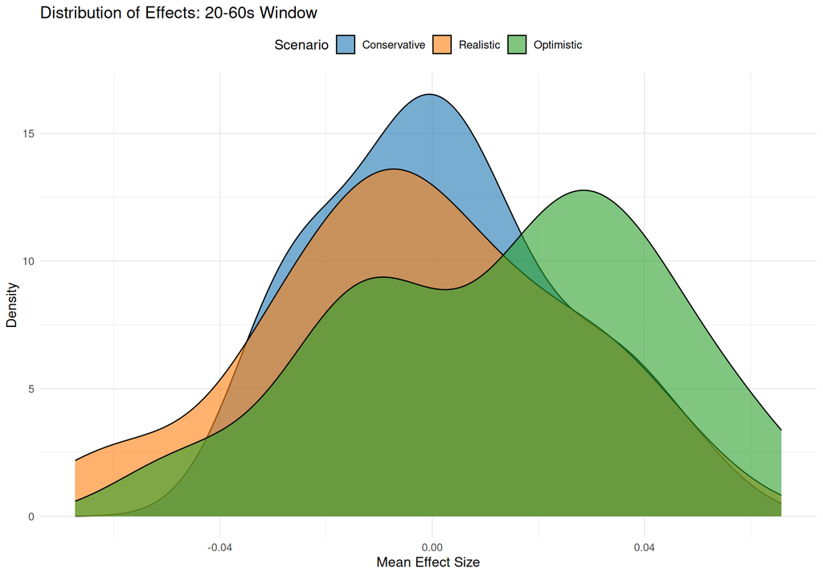

```r
ggplot(all_data, aes(x = mean_20_60s, fill = scenario)) +
  geom_density(alpha = 0.6) +
  scale_fill_manual(values = c("Conservative" = "#1f77b4",
                               "Realistic" = "#ff7f0e",
                               "Optimistic" = "#2ca02c")) +
  labs(title = "Distribution of Effects: 20-60s Window",
       x = "Mean Effect Size",
       y = "Density",
       fill = "Scenario") +
  theme_minimal() +
  theme(legend.position = "top", text = element_text(size = 12))
```

### Boxplot Comparison Across Scenarios

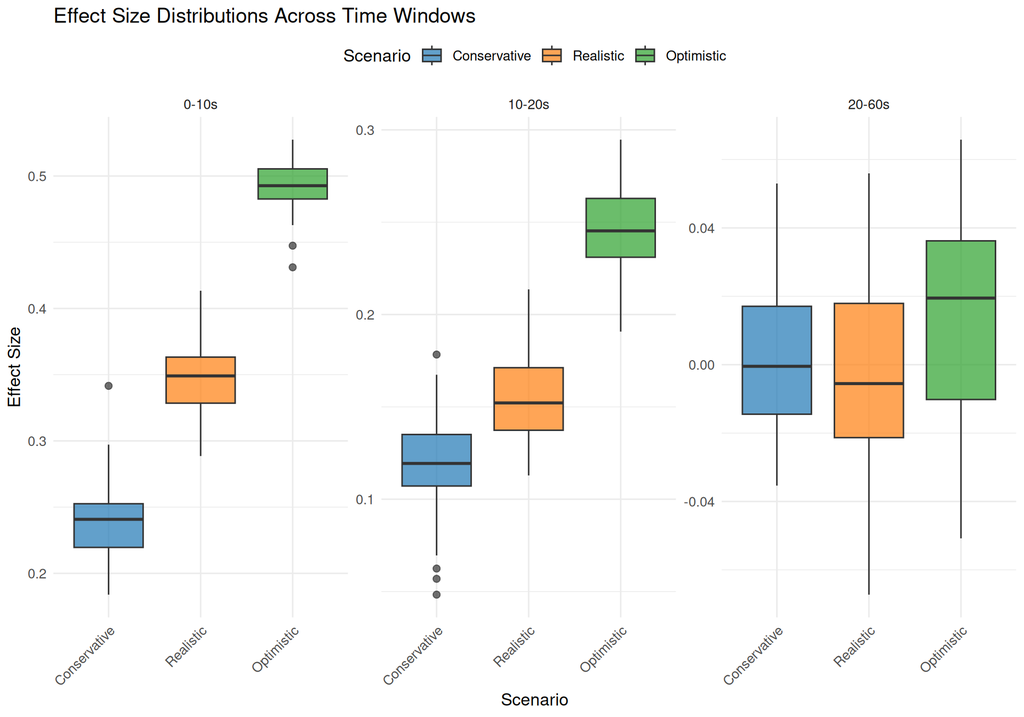

```r
# Prepare data for boxplot
plot_data <- all_data %>%
  pivot_longer(cols = c(mean_0_10s, mean_10_20s, mean_20_60s),
               names_to = "time_window",
               values_to = "effect_size") %>%
  mutate(time_window = case_when(
    time_window == "mean_0_10s" ~ "0-10s",
    time_window == "mean_10_20s" ~ "10-20s",
    time_window == "mean_20_60s" ~ "20-60s"
  ))

ggplot(plot_data, aes(x = scenario, y = effect_size, fill = scenario)) +
  geom_boxplot(alpha = 0.7, outlier.size = 2) +
  facet_wrap(~time_window, scales = "free_y") +
  scale_fill_manual(values = c("Conservative" = "#1f77b4",
                               "Realistic" = "#ff7f0e",
                               "Optimistic" = "#2ca02c")) +
  labs(title = "Effect Size Distributions Across Time Windows",
       x = "Scenario",
       y = "Effect Size",
       fill = "Scenario") +
  theme_minimal() +
  theme(legend.position = "top",
        axis.text.x = element_text(angle = 45, hjust = 1),
        text = element_text(size = 12))
```

### Mean Effects with Confidence Intervals

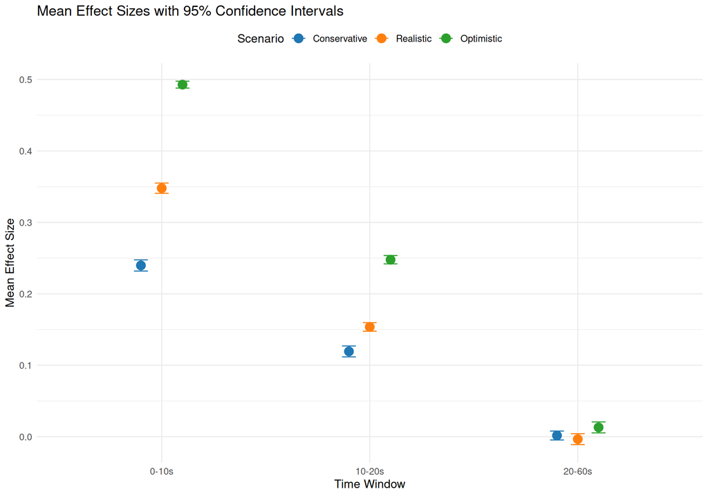

```r
# Calculate means and CIs for each scenario and time window
ci_data <- all_data %>%
  pivot_longer(cols = c(mean_0_10s, mean_10_20s, mean_20_60s),
               names_to = "Time_Window",
               values_to = "Effect_Size") %>%
  mutate(Time_Window = case_when(
    Time_Window == "mean_0_10s" ~ "0-10s",
    Time_Window == "mean_10_20s" ~ "10-20s",
    Time_Window == "mean_20_60s" ~ "20-60s"
  )) %>%
  group_by(scenario, Time_Window) %>%
  summarise(
    Mean = mean(Effect_Size, na.rm = TRUE),
    SD = sd(Effect_Size, na.rm = TRUE),
    N = n(),
    .groups = "drop"
  ) %>%
  mutate(
    SE = SD / sqrt(N),
    CI_lower = Mean - 1.96 * SE,
    CI_upper = Mean + 1.96 * SE
  )

ggplot(ci_data, aes(x = Time_Window, y = Mean, color = scenario)) +
  geom_point(size = 4, position = position_dodge(width = 0.3)) +
  geom_errorbar(aes(ymin = CI_lower, ymax = CI_upper),
                width = 0.2, position = position_dodge(width = 0.3)) +
  scale_color_manual(values = c("Conservative" = "#1f77b4",
                                "Realistic" = "#ff7f0e",
                                "Optimistic" = "#2ca02c")) +
  labs(title = "Mean Effect Sizes with 95% Confidence Intervals",
       x = "Time Window",
       y = "Mean Effect Size",
       color = "Scenario") +
  theme_minimal() +
  theme(legend.position = "top", text = element_text(size = 12))
```

### Hypothesis Support Rates

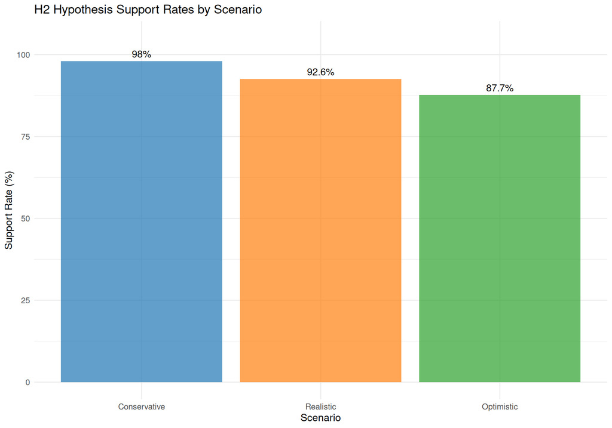

```r
h2_plot_data <- all_data %>%
  group_by(scenario) %>%
  summarise(
    Support_Rate = mean(h2_supported, na.rm = TRUE) * 100
  )

ggplot(h2_plot_data, aes(x = scenario, y = Support_Rate, fill = scenario)) +
  geom_col(alpha = 0.7) +
  scale_fill_manual(values = c("Conservative" = "#1f77b4",
                               "Realistic" = "#ff7f0e",
                               "Optimistic" = "#2ca02c")) +
  geom_text(aes(label = paste0(round(Support_Rate, 1), "%")),
            vjust = -0.5, size = 4) +
  ylim(0, 105) +
  labs(title = "H2 Hypothesis Support Rates by Scenario",
       x = "Scenario",
       y = "Support Rate (%)",
       fill = "Scenario") +
  theme_minimal() +
  theme(legend.position = "none", text = element_text(size = 12))
```

## Key Findings

### Effect Size Patterns

1. **0-10s Window**: Shows strong, consistent effects across all scenarios
   - Conservative: 0.240 ± 0.028
   - Realistic: 0.348 ± 0.027
   - Optimistic: 0.493 ± 0.019
2. **10-20s Window**: Shows smaller but still substantial effects
   - Conservative: 0.119 ± 0.028
   - Realistic: 0.154 ± 0.022
   - Optimistic: 0.248 ± 0.023
3. **20-60s Window**: Effects diminish to near-zero
   - All scenarios: Effects cluster around 0 (range: -0.003 to +0.013)

### Hypothesis Support

- **Conservative scenario**: Highest support rate (98.04%)
- **Realistic scenario**: Moderate support rate (92.59%)
- **Optimistic scenario**: Lower support rate (87.72%)

The inverse relationship between effect size assumptions and support rates suggests that more stringent criteria in conservative scenarios lead to more consistent hypothesis support.

## Conclusions

1. **Temporal Decay**: Effects show clear temporal decay across the three time windows
2. **Scenario Sensitivity**: Effect size assumptions significantly impact observed results
3. **Reliability**: Conservative assumptions provide most reliable hypothesis confirmation
4. **Time Window Importance**: The 0-10s window carries the most informative signal

*Report generated on 2026-02-10 09:08:55*